# Lab 8

Hope Hahn

2024-03-06

## Forest Cover Classification with SVM

In this week’s lab we are exploring the use of Support Vector Machines for multi-class classification. Specifically, you will be using cartographic variables to predict forest cover type (7 types).

Natural resource managers responsible for developing ecosystem management strategies require basic descriptive information including inventory data like forest cover type for forested lands to support their decision-making processes. However, managers generally do not have this type of data for in-holdings or neighboring lands that are outside their immediate jurisdiction. One method of obtaining this information is through the use of predictive models.

You task is build both an SVM and a random forest model and compare their performance on accuracy and computation time.

1. The data is available here: https://ucsb.box.com/s/ai5ost029enlguqyyn04bnlfaqmp8kn4

Explore the data.

```r
# load in data
covtype1 <- read_csv(here::here("labs", "covtype_sample.csv")) %>%
    janitor::clean_names()

covtype2 <- covtype1 %>%
    mutate(cover_type = as.factor(cover_type))

# look at head of data
head(covtype1)
```

```
## # A tibble: 6 × 55
##   elevation aspect slope horizontal_distance_to_hydrology horizontal_distance_…¹
##       <dbl>  <dbl> <dbl>                            <dbl>                  <dbl>
## 1      3136    228     7                              810                     -7
## 2      2898    129    12                              201                      4
## 3      2765     74    16                              268                    134
## 4      3078    189    10                              582                    -39
## 5      3141    159    11                              466                    -33
## 6      2999    329     6                              636                     91
## # ℹ abbreviated name: ¹horizontal_distance_to_roadways
## # ℹ 50 more variables: hillshade_9am <dbl>, hillshade_noon <dbl>,
## #   hillshade_3pm <dbl>, horizontal_distance_to_fire_points <dbl>,
## #   wilderness_area_rawah <dbl>, wilderness_area_neota <dbl>,
## #   wilderness_area_comanche <dbl>, wilderness_area_poudre <dbl>,
## #   soil_type <dbl>, soil_type_1 <dbl>, soil_type_2 <dbl>, soil_type_3 <dbl>,
## #   soil_type_4 <dbl>, soil_type_5 <dbl>, soil_type_6 <dbl>, …
```

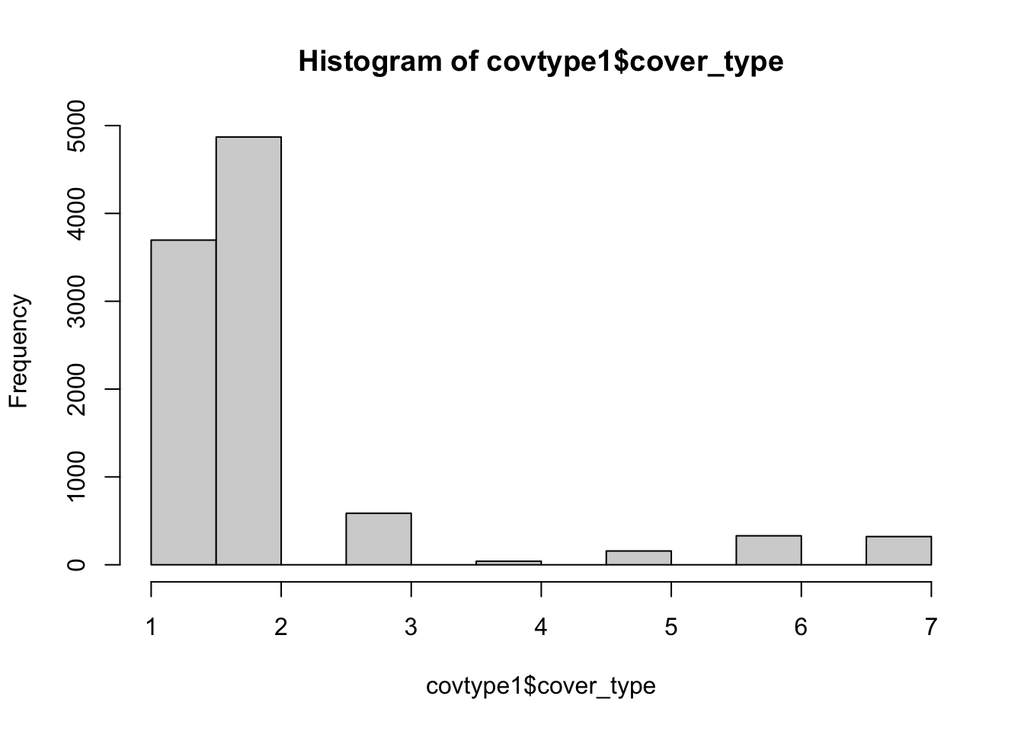

```r
hist(covtype1$cover_type)
```

- What kinds of features are we working with?
- **All the features in this dataset have numeric observations. All the soil types are a binary 0 or 1 and there is only one 1 per observation among all soil types. The wilderness areas are also binary. The cover type (dependent variable) are numbers, but they represent categories.**
- Does anything stand out that will affect you modeling choices?
- **The distribution of the cover type variable is very skewed and most of the observations fall in the first two categories. There are also many classes, which may make SVM not work as well.**

Hint: Pay special attention to the distribution of the outcome variable across the classes.

2. Create the recipe and carry out any necessary preprocessing. Can you use the same recipe for both models?
- **You can use the same recipe for both models.**

```r
# split data
covtype_split <- initial_split(covtype2, prop = 0.7, strata = cover_type)
covtype_train <- training(covtype_split)
covtype_test <- testing(covtype_split)

# create recipe
recipe <- recipe(cover_type ~ ., data = covtype_train) %>%
    step_zv(all_predictors()) %>%
    step_center(numeric()) %>%
    step_scale(numeric())
```

3. Create the folds for cross-validation.

```r
# create folds
cv_folds = vfold_cv(covtype_train, v = 10)
```

4. Tune the models. Choose appropriate parameters and grids. If the computational costs of tuning given your strategy are prohibitive, how might you work around this?
- **The computation costs for svm_poly was much too high, so I will be using svm_rbf instead. The computation for random forests is pretty long too, but is not too long, so I will be using the normal tuning process.**

*SVM*

```r
# create svm model spec
svm_rbf_spec <- svm_rbf() %>%
    set_mode("classification") %>%
    set_engine("kernlab")

# Fit the new specification
system.time(svm_rbf_fit <- svm_rbf_spec %>%
    fit(cover_type ~ ., data = covtype_train))
```

```
##    user  system elapsed
##   5.046   0.143   5.201
```

*RF*

```r
# random forest model spec
rf_model_spec <- rand_forest(mtry = tune(), trees = tune()) %>%
    set_engine("ranger") %>%
    set_mode("classification")

# create workflow
rf_workflow <- workflow() %>%
    add_model(rf_model_spec) %>%
    add_recipe(recipe)

# tune paramaters
system.time(rf_cv_tune <- rf_workflow %>%
    tune_grid(resamples = cv_folds, grid = 10))  #use cross validation to tune mtry and trees parameters
```

```
##     user   system  elapsed
## 1191.927    6.863 1165.660
```

```r
# finalize workflow to select best model
rf_final <- finalize_workflow(rf_workflow, select_best(rf_cv_tune,
    metric = "accuracy"))

# fit train data to model
train_fit_rf <- fit(rf_final, covtype_train)
```

*SVM*

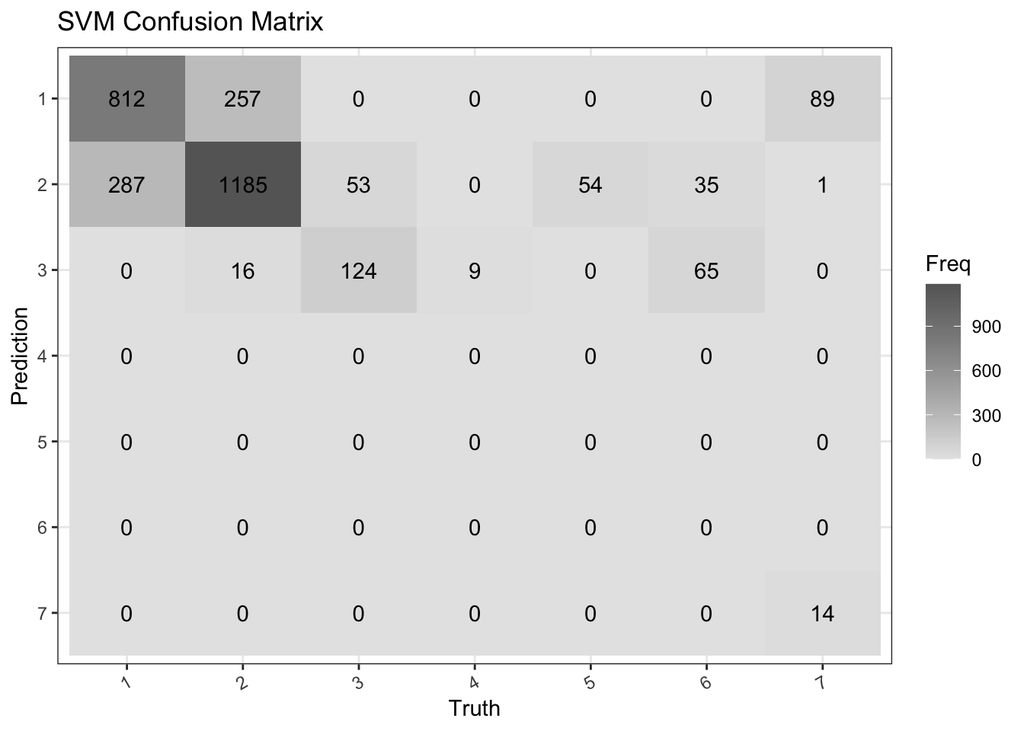

```r
test_predict_svm <- predict(object = svm_rbf_fit, new_data = covtype_test) %>%
  bind_cols(covtype_test)

accuracy_svm <- accuracy(test_predict_svm, truth = cover_type, estimate = .pred_class)

#Examine model performance via confusion matrix
augment(svm_rbf_fit, new_data = covtype_test) %>%
  conf_mat(truth = cover_type, estimate = .pred_class) %>%
  autoplot(type = "heatmap") + #plot confusion matrix with heatmap
  theme_bw() + #change theme
  theme(axis.text.x = element_text(angle = 30, hjust=1)) +
  #rotate axis labels
  labs(title = "SVM Confusion Matrix")
```

*RF*

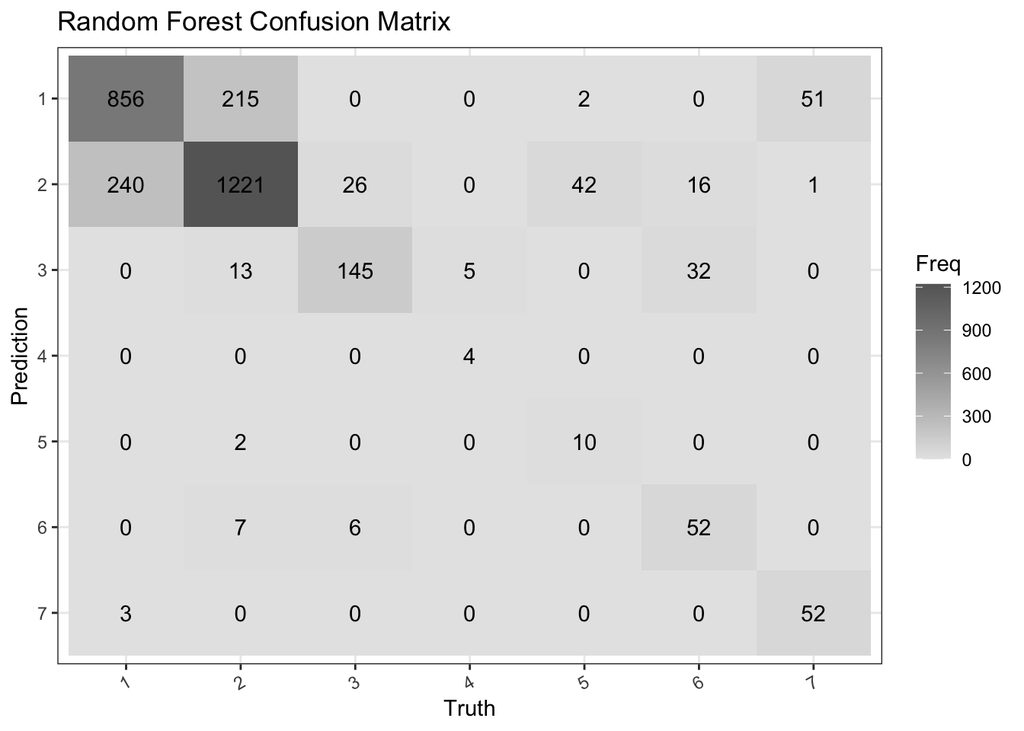

```r
# predict test data
test_predict_rf <- predict(train_fit_rf, covtype_test) %>% #get prediction probabilities for test data
  bind_cols(covtype_test)

# test accuracy
accuracy_rf <- accuracy(test_predict_rf, truth = cover_type, estimate = .pred_class)

# plot confustion matrix
test_predict_rf %>%
  conf_mat(truth = cover_type, estimate = .pred_class) %>% #create confusion matrix
  autoplot(type = "heatmap") + #plot confusion matrix with heatmap
  theme_bw() + #change theme
  theme(axis.text.x = element_text(angle = 30, hjust=1)) +
  #rotate axis labels
  labs(title = "Random Forest Confusion Matrix")
```

- Which type of model do you think is better for this task?
- **The random forest model is better for this task. The accuracy for the rf model was 0.7797401 while the accuracy of the svm model was 0.7114295.**
- Why do you speculate this is the case?
- **The random forest model is better for multiclass problems, while svm works better when there are only two classes. Random forest also works well when features are both numeric and categorical. Additionally, svm works better for smaller datasets, and this dataset was quite large. It is also possible that there was not a clear margin of separation among classes, which would make svm not work as well.**